# Introduction to Solving Biological Problems Using R - Day 2

## Linear Regression

- Linear modeling is supported by the function `lm()`:
  - `example(lm)`
- The output assumes you know a fair bit about the subject
- `lm` is really useful for plotting lines of best fit to XY data, in order to determine intercept, gradient and Pearson’s correlation coefficient
  - This is very easy in R
- Three steps to plotting with a best fit line:
  - Plot XY scatter-plot data
  - Fit a linear model
  - Add bestfit line data to plot with `abline()` function
- Let’s see a toy example:-

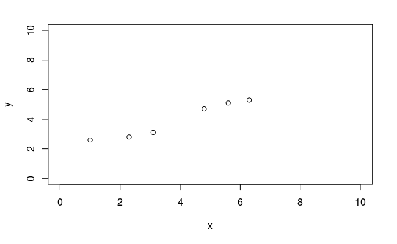

```r
x <- c(1, 2.3, 3.1, 4.8, 5.6, 6.3)
y <- c(2.6, 2.8, 3.1, 4.7, 5.1, 5.3)
plot(x,y, xlim=c(0,10), ylim=c(0,10))
```

- The `~` is used to define a formula; i.e. “y is given by x”
  - Take care about the order of `x` and `y` in the `plot` and `lm` expressions

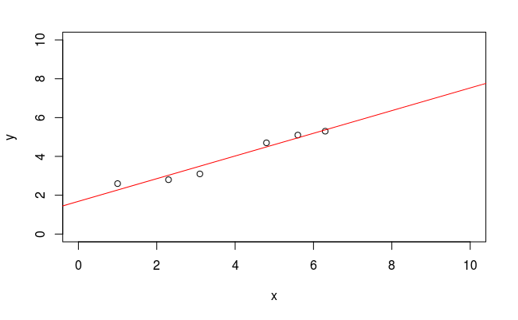

```r
plot(x,y, xlim=c(0,10), ylim=c(0,10))
myModel <- lm(y~x)
abline(myModel, col="red")
```

The generic `summary` function give an overview of the model

- particular components are accessible if we know their names

```r
summary(myModel)
```

```
Call:
lm(formula = y ~ x)

Residuals:
       1        2        3        4        5        6
 0.33159 -0.22785 -0.39520  0.21169  0.14434 -0.06458

Coefficients:
            Estimate Std. Error t value Pr(>|t|)
(Intercept)  1.68422    0.29056   5.796   0.0044 **
x            0.58418    0.06786   8.608   0.0010 **
---
Signif. codes:  0 ‘***’ 0.001 ‘**’ 0.01 ‘*’ 0.05 ‘.’ 0.1 ‘ ’ 1

Residual standard error: 0.3114 on 4 degrees of freedom
Multiple R-squared:  0.9488,    Adjusted R-squared:  0.936
F-statistic:  74.1 on 1 and 4 DF,  p-value: 0.001001
```

```r
names(myModel)  # Names of the objects within myModel
```

```
 [1] "coefficients"  "residuals"     "effects"       "rank"          "fitted.values" "assign"        "qr"            "df.residual"   "xlevels"
[10] "call"          "terms"         "model"
```

- alternatively, various helper functions are provided.

```r
coef(myModel)   # Coefficients
```

```
(Intercept)           x
  1.6842239   0.5841843
```

```r
resid(myModel)  # Residuals
```

```
          1           2           3           4           5           6
 0.33159186 -0.22784770 -0.39519512  0.21169160  0.14434418 -0.06458482
```

```r
fitted(myModel) # Fitted values
```

```
       1        2        3        4        5        6
2.268408 3.027848 3.495195 4.488308 4.955656 5.364585
```

```r
residuals(myModel) + fitted(myModel) # what values does this give?
```

```
  1   2   3   4   5   6
2.6 2.8 3.1 4.7 5.1 5.3
```

You can also get some diagnostic information on the model.

- Some explanation can be found [here](http://data.library.virginia.edu/diagnostic-plots/) and [here](http://strata.uga.edu/6370/rtips/regressionPlots.html)

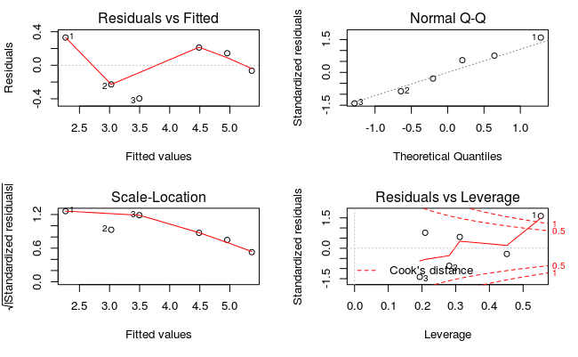

```r
par(mfrow=c(2,2))
plot(myModel)
```

- R has a very powerful formula syntax for describing statistical models
- Suppose we had two explanatory variables `x` and `z`, and one response variable `y`
- We can describe a relationship between, say, `y` and `x` using a tilde `~`, placing the response variable on the left of the tilde and the explanatory variables on the right:
  - y~x
- It is very easy to extend this syntax to do multiple regressions, ANOVAs, to include interactions, and to do many other common modelling tasks. For example

```r
y~x       #If x is continuous, this is linear regression
```

```
y ~ x
```

```r
y~x       #If x is categorical, ANOVA
```

```
y ~ x
```

```r
y~x+z     #If x and z are continuous, multiple regression
```

```
y ~ x + z
```

```r
y~x+z     #If x and z are categorical, two-way ANOVA
```

```
y ~ x + z
```

```r
y~x+z+x:z # : is the symbol for the interaction term
```

```
y ~ x + z + x:z
```

```r
y~x*z     # * is a shorthand for x+z+x:z
```

```
y ~ x * z
```

## Exercise: Exercise 6

- There are suggestions that Ozone level could be influenced by Temperature:

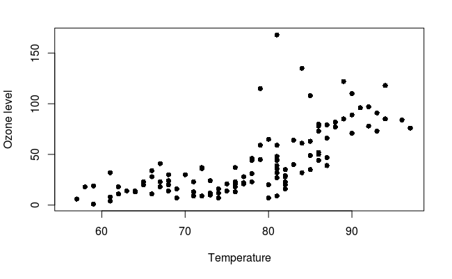

```r
plot(weather$Temp, weather$Ozone,xlab="Temperature",ylab="Ozone level",pch=16)
```

- Perform a linear regression analysis to assess this:
  - Fit the linear model and print a summary of the output
  - Plot the two variables and overlay a best-fit line
  - What is the equation of the best-fit line in the form
    $$y = ax + b$$
- Calculate the correlation between the two variables using the function cor (?cor)
  - can you add text to the plot to show the correlation coefficient?
  - HINT: The `paste` can be used to join strings of text together, or variables

```r
paste("Hello","World")
```

```
[1] "Hello World"
```

```r
age <- 35
paste("My age is", age)
```

```
[1] "My age is 35"
```

```r
## Your Answer Here ##
```

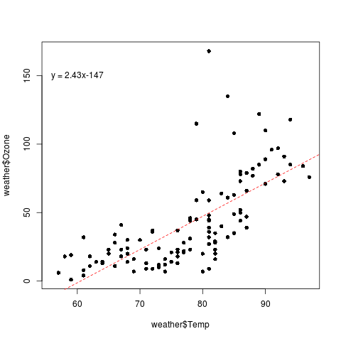

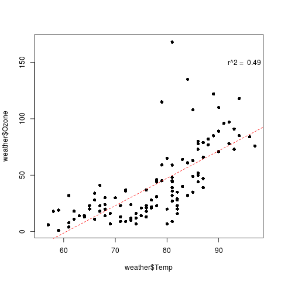

## More words of warning

*Correlation != Causation*

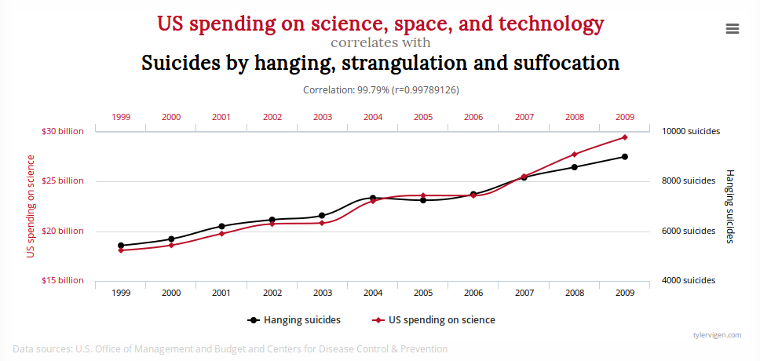

http://tylervigen.com/spurious-correlations

[figure not shown]

[So if I want to win a nobel prize, I should eat even more chocolate?!?!?](http://www.businessinsider.com/chocolate-consumption-vs-nobel-prizes-2014-4?IR=T)

But no-one would ever take such trends seriously….would they?

[figure not shown]

Cutting-down on Ice Cream was recommended as a safeguard against polio!